# Task5

Tomas Kozlovskis

Tuesday, March 15, 2016

Šioje užduotyje reikia atlikti tiesinę regresiją. Pakete dynlm yra duomenų masyvas M1Germany - ten yra ir jo aprašymas. Iš turimų duomenų sudarykite ir įvertinkite tiesinę regresiją, kurios endogeninis kintamasis yra logm1. Lygtis būtų naudojama prognozuoti pinigų kiekį artimiausiam laikotarpiui į prieki remiantis dabartine situacija. Taigi prognozės sudarymui lygtis gali naudoti tik tuos duomenis, kurie būtų žinomi prognozavimo momentu.

Taigi, pradžioje įsivedame duomenis ir juos apžvelgiame.

```r
library(dynlm)
library(car)
library(lmtest)

duom<-M1Germany
del<-c(145,146,147)
duom<-duom[-del,]
head(duom)
```

```
##            logm1 logprice   loggnp interest
## 1960 Q1 7.947090 3.403827 8.309448    0.062
## 1960 Q2 7.996191 3.380212 8.387236    0.064
## 1960 Q3 7.949908 3.436211 8.465361    0.064
## 1960 Q4 8.030746 3.419888 8.477333    0.062
## 1961 Q1 7.951792 3.449861 8.374404    0.060
## 1961 Q2 8.020040 3.427157 8.420854    0.057
```

Matome, jog matavimo intervalas yra ketvirtis (3 mėnesiai). Kuriame kelis modelius, bet atrenkame patį geriausią, pagal jo Akaike information criteria ir R-Squared koeficientus.

```r
mod<-dynlm(logm1~L(logprice,4)+d(L(loggnp,4))+L(interest,4), duom)
summary(mod)
```

```
##
## Time series regression with "zooreg" data:
## Start = 1961 Q2, End = 1995 Q4
##
## Call:
## dynlm(formula = logm1 ~ L(logprice, 4) + d(L(loggnp, 4)) + L(interest,
##     4), data = duom)
##
## Residuals:
##       Min        1Q    Median        3Q       Max
## -0.092358 -0.024378  0.000533  0.027716  0.086572
##
## Coefficients:
##                 Estimate Std. Error t value Pr(>|t|)
## (Intercept)      5.78080    0.03546 163.024  < 2e-16 ***
## L(logprice, 4)   0.71159    0.00821  86.673  < 2e-16 ***
## d(L(loggnp, 4))  0.33412    0.05710   5.852 3.51e-08 ***
## L(interest, 4)  -2.58344    0.24662 -10.476  < 2e-16 ***
## ---
## Signif. codes:  0 '***' 0.001 '**' 0.01 '*' 0.05 '.' 0.1 ' ' 1
##
## Residual standard error: 0.03846 on 135 degrees of freedom
## Multiple R-squared:  0.9824, Adjusted R-squared:  0.982
## F-statistic:  2516 on 3 and 135 DF,  p-value: < 2.2e-16
```

```r
summary(mod)$r.squared
```

```
## [1] 0.9824275
```

```r
AIC(mod)
```

```
## [1] -505.3912
```

```r
vif(mod)
```

```
##  L(logprice, 4) d(L(loggnp, 4))  L(interest, 4)
##        1.041727        1.005078        1.037565
```

Panaudoję vif funkciją, nepastebėjome multikolinearumo problemų.

Beliko patikrinti modelio liekanų normalumą ir įverčių paklaidų homoskedastiškumą.

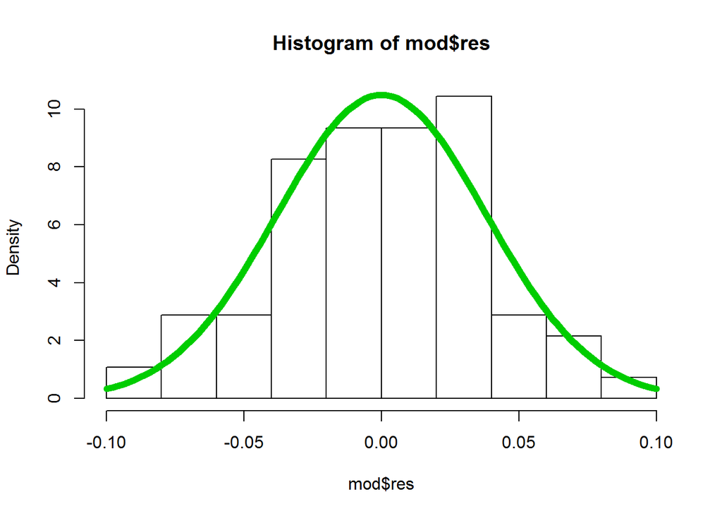

```r
hist(mod$res, probability = T)
curve(dnorm(x, mean=mean(mod$res), sd=sd(mod$res)), col=3, lwd=6, add=TRUE)
```

```r
shapiro.test(as.vector(mod$res))
```

```
##
##  Shapiro-Wilk normality test
##
## data:  as.vector(mod$res)
## W = 0.9902, p-value = 0.4431
```

P-value daugiau už 0.05, todėl neturime pagrindo atmesti H0 hipotezės, teigiančios, jog paklaidos yra normaliai pasiskirsčiusios.

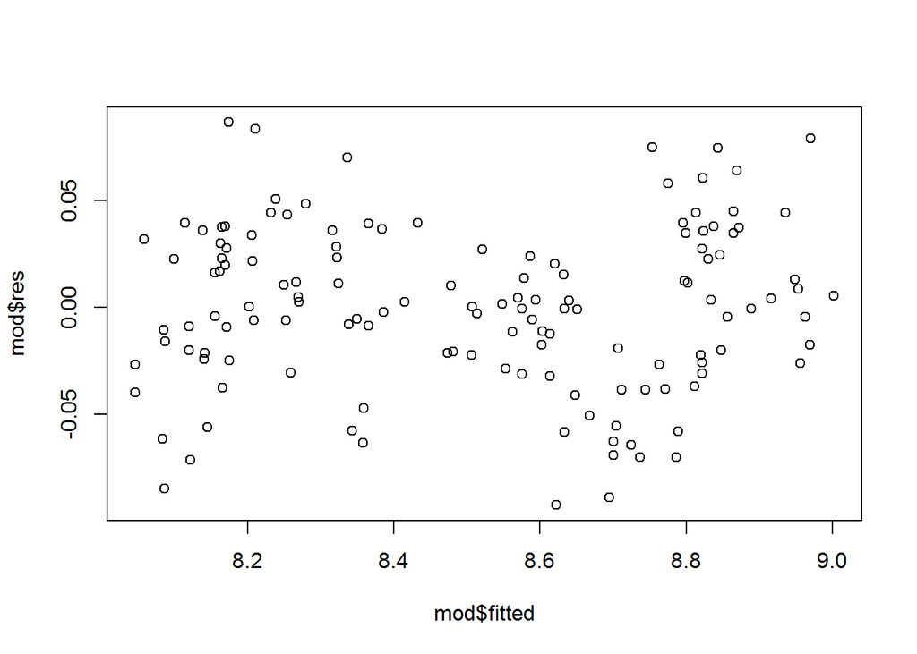

```r
plot(mod$res~mod$fitted)
```

```r
bptest(mod)
```

```
##
##  studentized Breusch-Pagan test
##
## data:  mod
## BP = 0.6355, df = 3, p-value = 0.8882
```

P-value yra daugiau už 0.05, todėl neturime pagrindo atmesti H0 hipotezės, teigiančios, jog modelis yra homoskedastiškas

Šios savybės leidžia manyti, jog modeliu galima pasitikėti ir jis gali būti naudingas prognozuojant.